# Multi-omics Data Analysis Workshop: Day 1

Paul Stewart

# Introduction

See https://github.com/pstew/mass_spec_multi-omics_2026/ if you have not already.

## Set up RStudio

Once R and RStudio are installed, open `mass_spec_multi-omics_2026.Rproj` in the supplied workshop folder and open this R Markdown file from `scripts/`. The package installation chunks are marked `eval = FALSE` so they can be run manually when needed. [RStudio Desktop download](https://posit.co/download/rstudio-desktop/).

Before we start writing or editing code, there are a few settings in RStudio that can make your experience much more comfortable. One helpful option is to turn on Soft Wrap, so that long lines of code or text automatically wrap within the editor window instead of scrolling off to the right. You can enable this by going to Tools -> Global Options -> Code -> Editing and checking Soft-wrap source files.

Another useful feature is Rainbow Parentheses, which color-matches pairs of parentheses and brackets to help you keep track of nesting. This is especially helpful when working with complex expressions. You can turn this on under Tools -> Global Options -> Code -> Display by checking Rainbow parentheses.

Finally, you may want to change the background color of the RStudio editor to something easier on the eyes. To do this, go to Tools -> Global Options -> Appearance and choose a different editor theme, such as “Tomorrow Night” for a dark background or “Textmate” for a clean, light look.

## R Markdown

This is an R Markdown file (or the PDF report generated from it, depending on what you are reading). R Markdown lets us combine regular text and executable code in a single document. You can run code chunks interactively or use the Knit button to create a formatted report (such as a PDF, HTML, or Word document). We will focus first on running code interactively and touch on reports towards the end. For the most part, code run through an R Markdown file are equivalent to them being run in the console.

In an R Markdown file, we use text characters to format other text that appear once the document is rendered into the formatted report.

- Lines that begin with # are section headers.
- # creates a main section
- ## creates a subsection
- *’s around some text will *italicize* it
- A single - followed by a space will make a bulleted list

Run a whole chunk with its green arrow. Cmd + Enter on a Mac or Ctrl + Enter on Windows runs the current line or selection. Output from a chunk appears underneath it.

# R mini tutorial

We will practice these R basics together before we open the protein table.

- Variables
- Vectors
- The `:` sequence operator
- Logical operators such as `==`, `!=`, `&`, `|`, and `!`
- The `%in%` operator
- Data frames
- Subsetting with brackets and `subset()`
- `for` loops

# Read in and view data

## Set the working directory

It is important that R knows where to look for your files. This is controlled by the working directory. If R is giving you an error about a file not existing but you are sure it does, then the most common problem is that the working directory was not set correctly (second most common is that there is a typo in your file location).

If we are using an R Project (which we are), the working directory is automatically set to the folder that contains the .Rproj file. However, since we are working in an R Markdown document, it may default the working directory to the location of the .Rmd file instead. This can be confusing, especially when code behaves differently depending on whether it is run in the console or inside chunks.

To fix this, we will explicitly set the working directory using the here package. This ensures that all file paths are interpreted relative to the folder where the R Project is located, rather than where the .Rmd file happens to live.

To install the here package, run this command in the console. The chunk below has the option eval = FALSE, which means it will not be evaluated when we knit the document or run all chunks at once. However, we can still run it manually using the green arrow or by placing your cursor in the chunk and pressing Ctrl + Enter (or Cmd + Enter on Mac).

```r
install.packages("here")
```

By default, this installs the package from CRAN, the Comprehensive R Archive Network (https://cran.r-project.org), which is the main repository for R packages (in addition to hosting the R package and source code).

Once it is installed, load the here package using

```r
library(here)
```

We will now add a setup chunk that sets the root directory for the entire document. We name it “setup” so it is easy to find; run it before the chunks that read files:

```r
here::i_am("scripts/Day01_proteomics.Rmd")
knitr::opts_knit$set(root.dir = here::here())
dir.create(here::here("work"), showWarnings = FALSE)
```

## Experimental data

Now let us load the protein abundance data (which we may also refer to as protein expression). We give it a short, descriptive variable name like prot so we know what the contents are without having to look at the contents. Header = TRUE means that the first row will be used for the column names, and row.names = 1 indicates that the first column will be used for the row names:

```r
prot_raw = read.delim("data/dia_lfq_protein_updated_headers_2026-07-16.txt",
                      header = TRUE, row.names = 1, check.names = FALSE)
prot = prot_raw # keep the original values so we can repeat the log2 step safely
```

Let us also load the meta data (subsequently referred to as “meta” for shorthand):

```r
meta = read.delim("data/sample_meta_2026-07-16.txt", header = TRUE)
```

We can look at the first few rows with the head() function:

```r
head(prot)
```

```
##             KO_TP_1  KO_TP_2  KO_TP_3  KO_TP_4  KO_TP_5 KO_baseline_1
## A0A087WNL7 11474.10 11282.30 11643.90 11380.40 10295.00       9160.92
## A0A087WPH7 30820.80 26099.50 26100.00 21899.40 12647.90      13000.30
## A0A087WQ16  3940.87  3468.04  4029.22  4074.38  3945.08       5428.93
## A0A087WQ32  3105.63  2958.71  3181.00  3436.47  2813.20       2402.61
## A0A087WQH8 24761.30 22779.10 19991.10 23988.70 21811.60      20409.80
## A0A087WQN7 15597.90 14915.60 16650.50 15111.10 15260.20      18220.00
##            KO_baseline_2 KO_baseline_3 KO_baseline_4 KO_baseline_5  WT_TP_1
## A0A087WNL7       9502.60      10262.80       8830.69       8811.47 17884.50
## A0A087WPH7      13811.50      17601.00      21117.60      16041.20 45882.20
## A0A087WQ16       5963.76       5768.15       5495.85       5258.89  5755.49
## A0A087WQ32       2231.49       2643.82       2792.94       2108.33  2445.45
## A0A087WQH8      17450.80      16773.30      19130.80      12470.50 15126.80
## A0A087WQN7      19931.70      18656.40      18633.60      18601.80 22733.40
##             WT_TP_2  WT_TP_3  WT_TP_4  WT_TP_5 WT_baseline_1 WT_baseline_2
## A0A087WNL7 18419.20 17171.40 20689.40 18759.20      12195.00      12179.40
## A0A087WPH7 26880.20 29827.60 31319.00 28735.40      21048.60      21009.90
## A0A087WQ16  6140.00  5701.61  6565.67  5523.40       6456.51       6252.31
## A0A087WQ32  2515.12  2573.07  2992.97  3270.87       1870.27       2234.11
## A0A087WQH8 26396.10 26077.90 23304.40 20414.10      13645.80      15457.50
## A0A087WQN7 22180.00 20287.60 21790.70 20775.90      20459.60      19026.50
##            WT_baseline_3 WT_baseline_4 WT_baseline_5
## A0A087WNL7      12448.30      12905.10      13872.00
## A0A087WPH7      27824.90      23312.30      28987.10
## A0A087WQ16       7033.00       6757.87       6734.30
## A0A087WQ32       3151.96       2610.88       2551.85
## A0A087WQH8      15301.20      14389.40      15566.50
## A0A087WQN7      20645.10      19840.50      19611.90
```

Given we have 20 samples this is a little crowded, and the rows wrap around so it is not very easy to interpret. Let us just look at the first five rows and first five columns using square brackets and the “:” sequence operator:

```r
prot[1:5, 1:5]
```

```
##             KO_TP_1  KO_TP_2  KO_TP_3  KO_TP_4  KO_TP_5
## A0A087WNL7 11474.10 11282.30 11643.90 11380.40 10295.00
## A0A087WPH7 30820.80 26099.50 26100.00 21899.40 12647.90
## A0A087WQ16  3940.87  3468.04  4029.22  4074.38  3945.08
## A0A087WQ32  3105.63  2958.71  3181.00  3436.47  2813.20
## A0A087WQH8 24761.30 22779.10 19991.10 23988.70 21811.60
```

We can look at the column names of prot

```r
head(names(prot))
```

```
## [1] "KO_TP_1"       "KO_TP_2"       "KO_TP_3"       "KO_TP_4"
## [5] "KO_TP_5"       "KO_baseline_1"
```

as well as the row names:

```r
head(row.names(prot))
```

```
## [1] "A0A087WNL7" "A0A087WPH7" "A0A087WQ16" "A0A087WQ32" "A0A087WQH8"
## [6] "A0A087WQN7"
```

The meta data is narrow enough that it will not be too crowded if we show the whole thing. We can just evaluate the data frame with no other arguments to display it:

```r
meta
```

```
##    Sample.number expression_column       group genotype condition replicate
## 1              1           KO_TP_1       KO_TP       KO        TP         1
## 2              2           KO_TP_2       KO_TP       KO        TP         2
## 3              3           KO_TP_3       KO_TP       KO        TP         3
## 4              4           KO_TP_4       KO_TP       KO        TP         4
## 5              5           KO_TP_5       KO_TP       KO        TP         5
## 6              6     KO_baseline_1 KO_baseline       KO  baseline         1
## 7              7     KO_baseline_2 KO_baseline       KO  baseline         2
## 8              8     KO_baseline_3 KO_baseline       KO  baseline         3
## 9              9     KO_baseline_4 KO_baseline       KO  baseline         4
## 10            10     KO_baseline_5 KO_baseline       KO  baseline         5
## 11            11           WT_TP_1       WT_TP       WT        TP         1
## 12            12           WT_TP_2       WT_TP       WT        TP         2
## 13            13           WT_TP_3       WT_TP       WT        TP         3
## 14            14           WT_TP_4       WT_TP       WT        TP         4
```

[output cut: 27 more lines]

Let us use the subset() function on meta, which takes a data frame as an argument and returns a filtered subset of the original data based on some criteria:

```r
meta_wt = subset(meta, genotype == "WT")
```

We can now use a very useful trick that forms the basis for most of our upcoming analyses. Say we only wanted the columns from the protein abundance for WT samples. We simply use meta_wt to get the columns we want from the protein data frame:

```r
head(prot[, meta_wt$expression_column])
```

```
##             WT_TP_1  WT_TP_2  WT_TP_3  WT_TP_4  WT_TP_5 WT_baseline_1
## A0A087WNL7 17884.50 18419.20 17171.40 20689.40 18759.20      12195.00
## A0A087WPH7 45882.20 26880.20 29827.60 31319.00 28735.40      21048.60
## A0A087WQ16  5755.49  6140.00  5701.61  6565.67  5523.40       6456.51
## A0A087WQ32  2445.45  2515.12  2573.07  2992.97  3270.87       1870.27
## A0A087WQH8 15126.80 26396.10 26077.90 23304.40 20414.10      13645.80
## A0A087WQN7 22733.40 22180.00 20287.60 21790.70 20775.90      20459.60
##            WT_baseline_2 WT_baseline_3 WT_baseline_4 WT_baseline_5
## A0A087WNL7      12179.40      12448.30      12905.10      13872.00
## A0A087WPH7      21009.90      27824.90      23312.30      28987.10
## A0A087WQ16       6252.31       7033.00       6757.87       6734.30
## A0A087WQ32       2234.11       3151.96       2610.88       2551.85
## A0A087WQH8      15457.50      15301.20      14389.40      15566.50
## A0A087WQN7      19026.50      20645.10      19840.50      19611.90
```

This code produces the same result:

```r
head(prot[, meta_wt[, "expression_column"]])
```

```
##             WT_TP_1  WT_TP_2  WT_TP_3  WT_TP_4  WT_TP_5 WT_baseline_1
## A0A087WNL7 17884.50 18419.20 17171.40 20689.40 18759.20      12195.00
## A0A087WPH7 45882.20 26880.20 29827.60 31319.00 28735.40      21048.60
## A0A087WQ16  5755.49  6140.00  5701.61  6565.67  5523.40       6456.51
## A0A087WQ32  2445.45  2515.12  2573.07  2992.97  3270.87       1870.27
## A0A087WQH8 15126.80 26396.10 26077.90 23304.40 20414.10      13645.80
## A0A087WQN7 22733.40 22180.00 20287.60 21790.70 20775.90      20459.60
##            WT_baseline_2 WT_baseline_3 WT_baseline_4 WT_baseline_5
## A0A087WNL7      12179.40      12448.30      12905.10      13872.00
## A0A087WPH7      21009.90      27824.90      23312.30      28987.10
## A0A087WQ16       6252.31       7033.00       6757.87       6734.30
## A0A087WQ32       2234.11       3151.96       2610.88       2551.85
## A0A087WQH8      15457.50      15301.20      14389.40      15566.50
## A0A087WQN7      19026.50      20645.10      19840.50      19611.90
```

This approach avoids hardcoding the wild type samples where we specify the column numbers:

```r
head(prot[, 11:20])
```

```
##             WT_TP_1  WT_TP_2  WT_TP_3  WT_TP_4  WT_TP_5 WT_baseline_1
## A0A087WNL7 17884.50 18419.20 17171.40 20689.40 18759.20      12195.00
## A0A087WPH7 45882.20 26880.20 29827.60 31319.00 28735.40      21048.60
## A0A087WQ16  5755.49  6140.00  5701.61  6565.67  5523.40       6456.51
## A0A087WQ32  2445.45  2515.12  2573.07  2992.97  3270.87       1870.27
## A0A087WQH8 15126.80 26396.10 26077.90 23304.40 20414.10      13645.80
## A0A087WQN7 22733.40 22180.00 20287.60 21790.70 20775.90      20459.60
##            WT_baseline_2 WT_baseline_3 WT_baseline_4 WT_baseline_5
## A0A087WNL7      12179.40      12448.30      12905.10      13872.00
## A0A087WPH7      21009.90      27824.90      23312.30      28987.10
## A0A087WQ16       6252.31       7033.00       6757.87       6734.30
## A0A087WQ32       2234.11       3151.96       2610.88       2551.85
## A0A087WQH8      15457.50      15301.20      14389.40      15566.50
## A0A087WQN7      19026.50      20645.10      19840.50      19611.90
```

What if we specify columns 11-20 are originally WT, but then we change the data by adding or removing samples? Then columns 11-20 may no longer correspond to WT, and our subsequent analyses will be wrong. By using the expression_column from the meta, we will always be sure to get the wild type samples, regardless of their order. Importantly, this only works if header = TRUE was used when we read in the protein data such that meta_wt$expression_column corresponds to the header/column names of prot. If we need to delete a specific sample, then we should refer to it by its specific name (e.g. WT_TP_4) instead of the specific column (e.g. column 14).

## Questions

For this and future questions, create your own chunk in this markdown file after the questions. Bonus points if you can find the keyboard shortcut for making a new chunk (hint: it is in one of the drop-down menus).

1. Data frames are examples of an object. Different objects have different properties. Prot and meta are both data frames. What happens if you put nrow(prot) in your chunk and run it? ncol(prot)? dim(prot)? summary(prot)?
2. Make a variable called fav_num, and assign your favorite number to it. What happens when you try to get the number of rows from it? What about summary()?
3. How would you display the head of only the TP samples?
4. Try running mean(prot) or sd(prot). What happens, and why? How could you make it work for a single column?
5. What does class(meta) return? What about typeof(meta)?
6. Try printing the first few row names using head(row.names(meta)). Do any of them match the column names of prot?
7. Create your own subset of meta for only the TP timepoint. Can you use it to select the corresponding columns from prot?
8. What does head(meta, 10) do? head(meta, 15)? head(meta, 21)?

# Visualize data

## Boxplot

R has a built-in boxplot() function that can take a data frame as input:

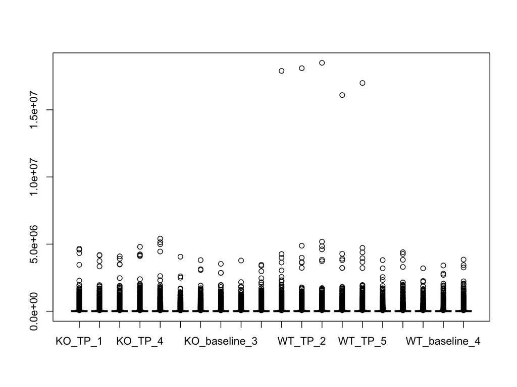

```r
boxplot(prot[, meta$expression_column])
```

Each box summarizes the protein intensities for one sample. The line inside the box is the median, the middle value when we put the measurements in order. The bottom and top of the box mark the 25th and 75th percentiles, so the box contains the middle 50% of the values. The distance between these edges is the interquartile range, or IQR.

The whiskers extend to the lowest and highest observed values that are within 1.5 times the IQR of the corresponding box edge. Values beyond those limits appear as separate circles (or sometimes dots) and are called outliers. Here, outlier means a value falls beyond this plotting cutoff, but it does not automatically mean the measurement is wrong or should be removed.

The result is not very informative. Proteomics intensities are often strongly right-skewed. This means many values cluster at the lower end, while a few extreme values stretch the plot upward, and plotting the values spans many orders of magnitude. As a result, it can be difficult to see detail in the lower part of the distribution. Additionally, the sample labels are not displaying clearly, making the plot harder to interpret.

To improve this, we will start by applying a log2 transformation to the intensity values. This often makes the distribution more symmetric and makes ratios easier to interpret. A log2 transformation alone does not guarantee that the assumptions of a statistical test are satisfied.

Each time we run this chunk, we start with `prot_raw` and make a fresh log2-transformed table called `prot`. If you rerun it after filtering, run the filter again before moving on.

```r
prot = log2(prot_raw[, meta$expression_column, drop = FALSE])
prot[1:5, 1:5]
```

```
##             KO_TP_1  KO_TP_2  KO_TP_3  KO_TP_4  KO_TP_5
## A0A087WNL7 13.48609 13.46177 13.50729 13.47426 13.32966
## A0A087WPH7 14.91162 14.67173 14.67176 14.41860 13.62661
## A0A087WQ16 11.94430 11.75990 11.97628 11.99236 11.94584
## A0A087WQ32 11.60067 11.53075 11.63526 11.74671 11.45800
## A0A087WQH8 14.59580 14.47542 14.28707 14.55007 14.41281
```

The observed intensities in this dataset are all positive and finite. If your dataset has zeros, negative values, or infinities and you decide they should be treated as missing, you can use brackets to replace those entries before taking `log2()`.

Now that the data has been log2-transformed, let us replot it. Note that due to size constraints, there may be some overlap in the plot elements when this is knit into a PDF.

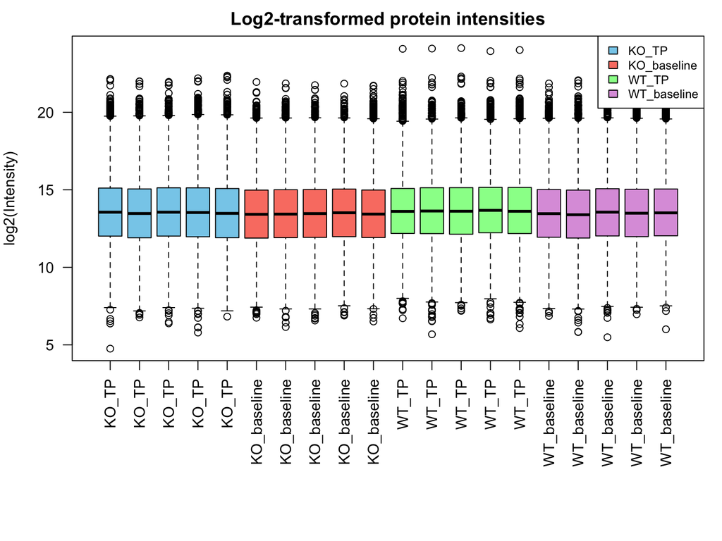

```r
# Increase bottom margin to fit longer x-axis labels; the pattern is bottom, left, top, right
par(mar = c(10, 4, 2, 1))

# Draw boxplot
boxplot(
  prot[, meta$expression_column],
  # use color directly from metadata
  col = meta$color,
  # x-axis labels = group names
  names = meta$group,
  las = 2,
  xlab = "",
  ylab = "log2(Intensity)",
  main = "Log2-transformed protein intensities"
)

# Add legend (one entry per unique group-color combo)
legend_groups = unique(meta[, c("group", "color")])

legend(
  "topright",
  legend = legend_groups$group,
  fill = legend_groups$color,
  # scaling of the legend
  cex = 0.8
)
```

It is now much easier to see what is happening in the data. After applying the log2 transformation, the intensities no longer span several orders of magnitude. Instead, the values are compressed into a more manageable range, roughly between 5 and 25 on the log2 scale. Notice how the medians nearly form a straight line across the boxes. Similar medians are consistent with prior LFQ processing, but a boxplot alone does not establish that normalization was adequate.

We should always watch for samples that behave abnormally in plots like these. For example, a sample with a much lower median than the others, even after normalization, might indicate a technical issue or sample failure. Color is also a helpful tool in data visualization. Here, the use of distinct colors makes it easy to separate the groups visually, even without referring to the legend.

## Boxplot with ggplot2

While we will emphasize a lot of plotting using base R in this workshop, we will also take a look at the ggplot2 package. ggplot2 is part of the tidyverse suite of R packages, and it’s a powerful system for creating more polished and customizable plots. However, it usually requires more code and additional data preparation, especially for grouped plots like boxplots across multiple samples. When possible, we will stick to simpler base R plots to keep things clear and introduce ggplot2 when we want more flexibility or aesthetics, but for the sake of demonstration let us make a box plot with ggplot2.

We will reuse the log2 intensities already stored in `prot`. For the ggplot2 version, we also need a few packages to prepare and plot the data.

```r
install.packages(c("tidyr", "dplyr", "ggplot2", "stringr"))
```

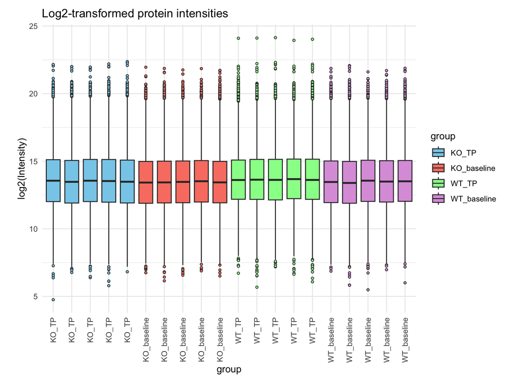

```r
library(tidyr)
library(dplyr)
library(ggplot2)

# Subset protein abundance data
expression_data = prot[
  ,
  meta$expression_column,
  drop = FALSE
]

# Preserve protein names before reshaping
expression_data$protein = rownames(expression_data)

# Reshape to long format and add sample metadata
long_df = expression_data %>%
  pivot_longer(
    cols = -protein,
    names_to = "expression_column",
    values_to = "intensity"
  ) %>%
  left_join(
    meta[, c(
      "expression_column",
      "group",
      "color"
    )],
    by = "expression_column"
  ) %>%
  filter(
    is.finite(intensity)
  )

# Order samples exactly as they appear in meta
long_df$expression_column = factor(
  long_df$expression_column,
  levels = meta$expression_column
)

# Order groups by their first appearance in meta
group_order = unique(meta$group)

long_df$group = factor(
  long_df$group,
  levels = group_order
)

# Match each sample column to its displayed group label
x_labels = setNames(
  meta$group,
  meta$expression_column
)

# Create a named group-to-color vector in the same order
group_colors = meta %>%
  distinct(group, color) %>%
  mutate(
    group = factor(
      group,
      levels = group_order
    )
  ) %>%
  arrange(group)

group_colors = setNames(
  group_colors$color,
  as.character(group_colors$group)
)

# Plot one box per sample
ggplot(
  long_df,
  aes(
    x = expression_column,
    y = intensity,
    fill = group
  )
) +
  geom_boxplot(
    outlier.shape = 21,
    outlier.size = 1
  ) +
  scale_x_discrete(
    labels = x_labels,
    drop = FALSE
  ) +
  scale_fill_manual(
    values = group_colors,
    breaks = group_order,
    drop = FALSE
  ) +
  theme_minimal() +
  theme(
    axis.text.x = element_text(
      angle = 90,
      vjust = 0.5,
      hjust = 1
    ),
    plot.margin = margin(
      10,
      10,
      10,
      20
    )
  ) +
  labs(
    x = "group",
    y = "log2(Intensity)",
    title = "Log2-transformed protein intensities",
    fill = "group"
  )
```

## Principal Component Analysis (PCA)

Principal Component Analysis (PCA) is a very important dimension reduction technique. PCA works by identifying new axes, called principal components (PCs), that capture the most variability in the data. Instead of plotting hundreds or thousands of features, PCA reduces this to just a few new dimensions that explain the overall structure. We usually focus on the first two principal components, since they explain the largest amount of variation, but additional components can also be explored.

To run PCA, we need a numerical matrix with no missing values. First we will remove proteins missing in half or more of the samples.

```r
row_na_threshold = 0.5
keep_rows = rowMeans(is.na(prot)) < row_na_threshold
coverage_summary = table(kept = keep_rows)
coverage_summary
```

```
## kept
## FALSE  TRUE
##   180  7229
```

```r
prot = prot[keep_rows, , drop = FALSE]
```

For the PCA and heatmap, we will replace missing values with the minimum observed log2 intensity in a separate matrix called `prot_imputed` (this approach can create or exaggerate separation when missingness differs by group). The `prot` table will keep its missing values for statistical testing.

`prcomp()` gives us the standard deviation of each principal component in `$sdev`. Square those values to get the variances. Divide each variance by the sum of all the component variances and multiply by 100 to get the percent variance explained by each component.

```r
min_value = min(as.matrix(prot), na.rm = TRUE)
prot_imputed = as.matrix(prot)
prot_imputed[is.na(prot_imputed)] = min_value

# Remove constant rows because they cannot be divided by their SD.
pca_keep = apply(prot_imputed, 1, sd) > 0
prot_imputed = prot_imputed[pca_keep, , drop = FALSE]

# prcomp expects samples in rows and features in columns.
prot_for_pca = t(prot_imputed)
pca_result = prcomp(prot_for_pca, center = TRUE, scale. = TRUE)
pc_variance = pca_result$sdev^2
pct_variance = 100 * pc_variance / sum(pc_variance)
```

Centering subtracts each protein’s mean and scaling divides by its standard deviation, which puts proteins on comparable scales. Once PCA is complete, we will visualize the first two principal components in a scatter plot, colored by group using the values from meta$color.

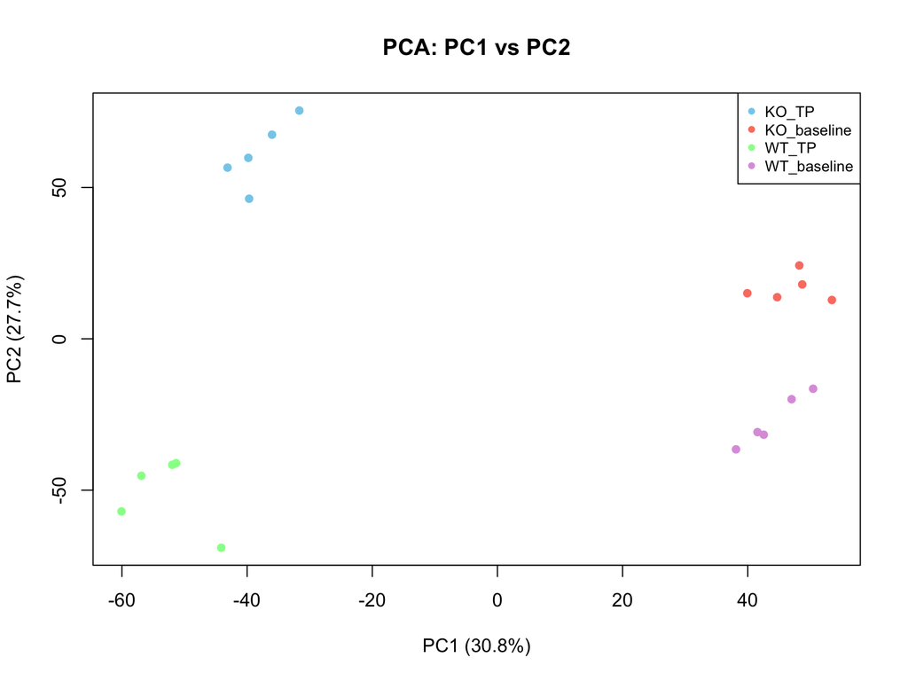

```r
# Extract PCA scores
pca_scores = pca_result$x

# Plot the first two principal components using base R
plot(
  pca_scores[, 1], pca_scores[, 2],
  col = meta$color,
  pch = 16,
  xlab = paste0("PC1 (", round(pct_variance[1], 1), "%)"),
  ylab = paste0("PC2 (", round(pct_variance[2], 1), "%)"),
  main = "PCA: PC1 vs PC2"
)

# Add a legend to explain the colors
legend(
  "topright",
  legend = unique(meta$group),
  col = unique(meta$color),
  pch = 16,
  cex = 0.8
)
```

What a nice dataset! We can see distinct groups in the PCA. This is useful evidence of structure, but it does not prove that every difference is biological or predict how many proteins will pass an FDR cutoff.

## Heatmap

Heatmaps are another useful way to visualize our data and identify patterns across samples. A heatmap uses color to represent protein abundance, with proteins in rows and samples in columns. We can also use hierarchical clustering to group proteins and samples with similar abundance patterns, making it easier to see differences between groups.

We have already filtered out proteins with poor coverage and created prot_imputed for PCA. We will use this same matrix for our heatmap so that missing values do not interfere with clustering. Rather than including every protein, we typically focus on those that vary the most across samples. Proteins with very little variation are less useful for distinguishing samples and can make patterns harder to see.

Here, we will select the 1,000 most variable proteins based on their standard deviation across samples. To do this, we will use R’s apply() function, which lets us apply a function to every row or column of a matrix or data frame. Setting MARGIN = 1 tells R to work across rows, so apply(prot_imputed, 1, sd) calculates the standard deviation of each protein across all samples.

```r
# Select top 1000 proteins by standard deviation
protein_sds = apply(prot_imputed, MARGIN = 1, sd)
top_proteins = head(names(sort(protein_sds, decreasing = TRUE)), 1000)
top_prot = prot_imputed[top_proteins, , drop = FALSE]
```

Before plotting, we need to center and scale the data by performing a z-score transformation on each row. This step is important. Just like in PCA, large differences in raw intensity values can overwhelm the clustering and lead to misleading patterns. Without standardization, proteins with higher average abundance will cluster together not because they behave similarly across samples, but simply because their overall values are larger.

```r
# Z-score normalization (row-wise)
z_top_prot = t(scale(t(top_prot)))
```

After scaling, the heatmap will better reflect biological patterns of change rather than differences in measurement scale. Clusters of samples and features may emerge that reflect group structure or co-regulated proteins. The heatmap can also help detect outliers or technical artifacts.

To create our heatmap, we will use the ComplexHeatmap package. This package is part of Bioconductor (https://bioconductor.org), which is a specialized repository for bioinformatics tools in R. Unlike CRAN, which hosts general-purpose R packages, Bioconductor focuses on packages for analyzing genomic and other biological data. You install Bioconductor packages using the BiocManager package.

You can do so with the following code. This block checks whether BiocManager is installed, installs it if needed, and then uses it to install ComplexHeatmap (https://www.bioconductor.org/packages/release/bioc/html/ComplexHeatmap.html). You can copy and paste this into your R console:

```r
if (!require("BiocManager", quietly = TRUE))
    install.packages("BiocManager")
BiocManager::install("ComplexHeatmap")
```

Once the package is installed, we can prepare our data. We will select the top 1,000 most variable proteins based on standard deviation, apply z-score scaling to center and standardize each row (protein), and color the columns (samples) by group/genotype/condition from meta.

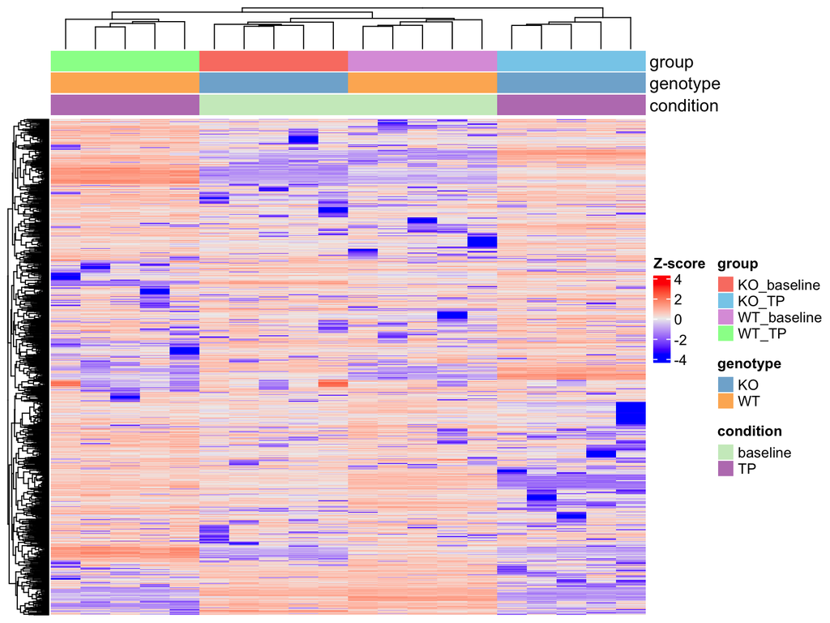

```r
# Load ComplexHeatmap
library(ComplexHeatmap)

# Group colors (already defined in meta)
legend_groups = unique(meta[, c("group", "color")])
# Create a named vector that maps each group name to its corresponding color.
group_colors_named = setNames(legend_groups$color, legend_groups$group)
# Define pastel but distinct hex colors
geno_colors = c(
  # soft orange
  "WT" = "#FDB462",
  # pastel blue (not skyblue)
  "KO" = "#80B1D3"
)

cond_colors = c(
  # light mint green
  "baseline" = "#CCEBC5",
  # muted violet
  "TP"       = "#BC80BD"
)

# Create column annotations
column_annot = HeatmapAnnotation(
  group = meta$group,
  genotype = meta$genotype,
  condition = meta$condition,
  col = list(
    group = group_colors_named,
    genotype = geno_colors,
    condition = cond_colors
  )
)

# Draw heatmap
Heatmap(
  z_top_prot,
  name = "Z-score",
  top_annotation = column_annot,
  show_column_names = FALSE,
  show_row_names = FALSE,
  cluster_rows = TRUE,
  cluster_columns = TRUE
)
```

## Questions

1. Create a new data frame with just the top 25 most variable proteins (by standard deviation). Try drawing a heatmap using just this smaller set.
2. Try setting cluster_rows = FALSE or cluster_columns = FALSE in your heatmap to see what changes.

# Annotate data

In proteomics datasets, protein identifiers often come as UniProt accessions such as `P12345`. Mapping them to gene symbols makes the plots easier to read and gives us identifiers for pathway analysis. For this dataset, we will use the supplied export from the [UniProt batch ID mapping tool](https://www.uniprot.org/id-mapping).

Load in the ID mapping data and take a look:

```r
id_map = read.delim("data/idmapping_2026_07_16.tsv", header = TRUE)
head(id_map)
```

```
##         From      Entry   Reviewed       Entry.Name
## 1 A0A087WNL7 A0A087WNL7 unreviewed A0A087WNL7_MOUSE
## 2 A0A087WPH7 A0A087WPH7 unreviewed A0A087WPH7_MOUSE
## 3 A0A087WQ16 A0A087WQ16 unreviewed A0A087WQ16_MOUSE
## 4 A0A087WQ32 A0A087WQ32 unreviewed A0A087WQ32_MOUSE
## 5 A0A087WQH8 A0A087WQH8            A0A087WQH8_MOUSE
## 6 A0A087WQN7 A0A087WQN7 unreviewed A0A087WQN7_MOUSE
##                                           Protein.names Gene.Names
## 1                 Snf2-related CREBBP activator protein      Srcap
## 2 Proteasome (prosome, macropain) 26S subunit, ATPase 3      Psmc3
## 3                           DNA mismatch repair protein       Msh3
## 4 GPI ethanolamine phosphate transferase 1 (EC 2.-.-.-)       Pign
## 5                                               deleted
## 6                 5'-3' exoribonuclease 1 (EC 3.1.13.-)       Xrn1
##               Organism Length
## 1 Mus musculus (Mouse)   3210
## 2 Mus musculus (Mouse)    305
## 3 Mus musculus (Mouse)   1095
## 4 Mus musculus (Mouse)    826
## 5                          NA
## 6 Mus musculus (Mouse)   1719
```

We need to match the gene names to the UniProt identifiers using the match() function. To understand how it works, let’s look at a simple example.

```r
letters = c("a", "b", "c", "d")
lookup = c("b", "d", "a", "c")
match(letters, lookup)
```

```
## [1] 3 1 4 2
```

This returns: 3 1 4 2 . It tells us that “a” is in position 3 of the lookup vector, “b” is in position 1, “c” is in position 4, and “d” is in position 2.

Now let us apply `match()` to our protein data. `Entry` contains the UniProt accession, and `Gene.Names` can contain more than one name. For example, the export lists `Kmt5a Setd8` for one entry. We keep `Kmt5a Setd8` in `gene_names` so we can still see and look up `Setd8` if we come across that name later. We use the first name, `Kmt5a`, as our working gene symbol. The accession stays with the protein throughout the analysis.

```r
# Match by accession because several proteins can share a gene name.
id_map_one = id_map[!duplicated(id_map$Entry), ]
match_positions = match(rownames(prot), id_map_one$Entry)

protein_annotation = data.frame(
  uniprot = rownames(prot),
  gene_names = id_map_one$Gene.Names[match_positions],
  stringsAsFactors = FALSE
)
```

We installed `stringr` with the plotting packages earlier. `str_squish()` removes extra spaces, and `word(..., 1)` takes the first word. If we have no gene name, we use the accession as the plot label.

```r
library(stringr)
word("Kmt5a Setd8", 1)
```

```
## [1] "Kmt5a"
```

```r
clean_gene_names = str_squish(protein_annotation$gene_names)
protein_annotation$gene_symbol = word(clean_gene_names, 1)
protein_annotation$gene_symbol[protein_annotation$gene_symbol == ""] = NA
protein_annotation$label = ifelse(
  is.na(protein_annotation$gene_symbol),
  protein_annotation$uniprot,
  protein_annotation$gene_symbol
)
table(mapped = !is.na(protein_annotation$gene_symbol))
```

```
## mapped
## FALSE  TRUE
##  1168  6061
```

```r
head(protein_annotation)
```

```
##      uniprot gene_names gene_symbol      label
## 1 A0A087WNL7      Srcap       Srcap      Srcap
## 2 A0A087WPH7      Psmc3       Psmc3      Psmc3
## 3 A0A087WQ16       Msh3        Msh3       Msh3
## 4 A0A087WQ32       Pign        Pign       Pign
## 5 A0A087WQH8                   <NA> A0A087WQH8
## 6 A0A087WQN7       Xrn1        Xrn1       Xrn1
```

For this exercise we use the first name in the supplied export. If an entry lists several names and you need to confirm which gene it refers to, look up the UniProt accession and check the gene name listed there.

# Differential protein abundance

## Hypothesis testing

Now that we have looked at the data and added gene annotations, we can ask which proteins differ in abundance between conditions. We will use Welch’s two-sample t-test to compare the group means on the log2 scale. The p-value depends on the size of the difference, the spread of the measurements within each group, and the number of observations. We will look at the difference itself as well so we can describe how much the abundance changed.

We will compare WT_baseline (group1) with WT_TP (group2). Positive fold change means higher abundance in group2. We will give the groups generic names so we can repeat the analysis by changing two lines. We assume these are independent biological replicates. If they were repeated measurements from the same animals, we would need a paired test or a model that includes animal ID.

```r
group1 = "WT_baseline"
group2 = "WT_TP"
group1_samples = subset(meta, group == group1)$expression_column
group2_samples = subset(meta, group == group2)$expression_column
stopifnot(length(group1_samples) >= 2, length(group2_samples) >= 2)

# Only abundance columns go into calculations, even after we add annotations.
comparison_matrix = as.matrix(prot[, c(group1_samples, group2_samples)])
```

## Plot and test two proteins by hand

Let us start with two proteins from this dataset, Anxa2 and Atp2a2. We chose them because they show different patterns in this comparison. Use the UniProt accession to pick a row and the sample names to pick the columns. Each dot is one mouse, and both panels use the same y-axis limits. Before running a test, which protein would you expect to have the smaller p-value?

```r
anxa2_group1 = comparison_matrix["P07356", group1_samples]
anxa2_group2 = comparison_matrix["P07356", group2_samples]
atp2a2_group1 = comparison_matrix["O55143", group1_samples]
atp2a2_group2 = comparison_matrix["O55143", group2_samples]
anxa2_group1
```

```
## WT_baseline_1 WT_baseline_2 WT_baseline_3 WT_baseline_4 WT_baseline_5
##      16.68774      16.74825      16.73587      16.85464      16.92683
```

```r
anxa2_group2
```

```
##  WT_TP_1  WT_TP_2  WT_TP_3  WT_TP_4  WT_TP_5
## 13.76474 13.76988 13.78560 13.71956 13.58430
```

Now we have two vectors for each protein, one for each group. For the plots, put the values from both groups in one column and give each value its group label in another column.

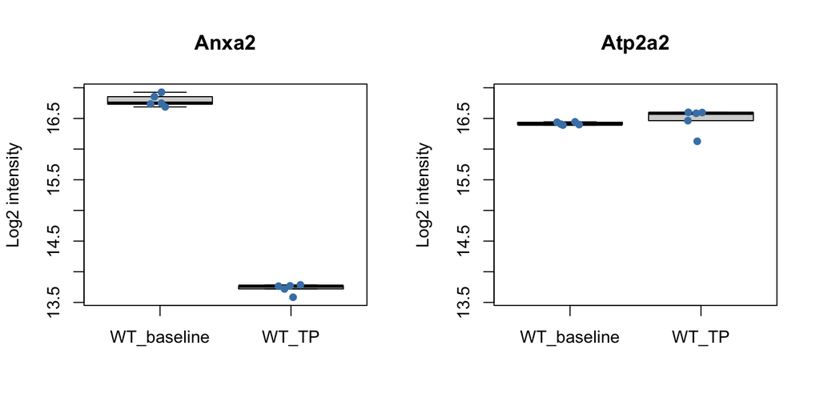

```r
plot_groups = rep(c(group1, group2),
                  c(length(group1_samples), length(group2_samples)))
plot_groups = factor(plot_groups, levels = c(group1, group2))
anxa2_plot = data.frame(intensity = c(anxa2_group1, anxa2_group2), group = plot_groups)
atp2a2_plot = data.frame(intensity = c(atp2a2_group1, atp2a2_group2), group = plot_groups)
shared_limits = range(anxa2_plot$intensity, atp2a2_plot$intensity, na.rm = TRUE)

par(mfrow = c(1, 2))
# Spread the points horizontally so we can see measurements that are close together.
set.seed(2026)
boxplot(intensity ~ group, data = anxa2_plot, ylim = shared_limits,
        outline = FALSE, xlab = "", ylab = "Log2 intensity", main = "Anxa2")
stripchart(intensity ~ group, data = anxa2_plot, vertical = TRUE,
           method = "jitter", add = TRUE, pch = 16, col = "steelblue")
boxplot(intensity ~ group, data = atp2a2_plot, ylim = shared_limits,
        outline = FALSE, xlab = "", ylab = "Log2 intensity", main = "Atp2a2")
stripchart(intensity ~ group, data = atp2a2_plot, vertical = TRUE,
           method = "jitter", add = TRUE, pch = 16, col = "steelblue")
```

```r
par(mfrow = c(1, 1))
```

Pass the `group2` vector to `t.test()` first so the confidence interval is for `group2 - group1`, the same direction we will use for the log2 fold change.

```r
anxa2_test = t.test(anxa2_group2, anxa2_group1)
atp2a2_test = t.test(atp2a2_group2, atp2a2_group1)
anxa2_test
```

```
##
##  Welch Two Sample t-test
##
## data:  anxa2_group2 and anxa2_group1
## t = -53.73, df = 7.7805, p-value = 2.772e-11
## alternative hypothesis: true difference in means is not equal to 0
## 95 percent confidence interval:
##  -3.198080 -2.933621
## sample estimates:
## mean of x mean of y
##  13.72482  16.79067
```

```r
atp2a2_test
```

```
##
##  Welch Two Sample t-test
##
## data:  atp2a2_group2 and atp2a2_group1
## t = 0.64077, df = 4.1077, p-value = 0.5557
## alternative hypothesis: true difference in means is not equal to 0
## 95 percent confidence interval:
##  -0.1916270  0.3081696
## sample estimates:
## mean of x mean of y
##  16.47403  16.41576
```

For the WT comparison, Anxa2 is lower in WT_TP and has a small p-value. The Atp2a2 group means are much closer together, and its p-value is much larger.

Use `$p.value` to pull out just the p-value. `p.value` is the name R gives it in the test result. In the full results table later, we name our column `pval`.

```r
anxa2_test$p.value
```

```
## [1] 2.771544e-11
```

```r
atp2a2_test$p.value
```

```
## [1] 0.5556744
```

These are the raw p-values. We will adjust for multiple testing once we have a p-value for every protein we can test.

## Repeat the comparison for every protein

Each row of `comparison_matrix` is a protein, so `apply()` with `1` repeats a calculation row by row. Let us start with the mean in each group and keep the results in a separate table.

```r
protein_results = protein_annotation
protein_results$group1_mean = apply(comparison_matrix[, group1_samples], 1, mean, na.rm = TRUE)
protein_results$group2_mean = apply(comparison_matrix[, group2_samples], 1, mean, na.rm = TRUE)
protein_results$n_group1 = rowSums(!is.na(comparison_matrix[, group1_samples]))
protein_results$n_group2 = rowSums(!is.na(comparison_matrix[, group2_samples]))
```

Remember `log2(a / b) = log2(a) - log2(b)`? Our values are already on the log2 scale, so we subtract the group means directly. That difference gives the log2 ratio of the geometric mean intensities.

```r
protein_results$group2_group1_log2fc = protein_results$group2_mean - protein_results$group1_mean
```

Now we can repeat the same Welch t-test for every row. `tryCatch()` records `NA` if a test cannot run.

```r
protein_results$pval = apply(comparison_matrix, 1, function(x) {
  x1 = x[group1_samples]
  x2 = x[group2_samples]
  x1 = x1[is.finite(x1)]
  x2 = x2[is.finite(x2)]
  tryCatch(t.test(x2, x1)$p.value, error = function(e) NA_real_)
})
table(testable = is.finite(protein_results$pval))
```

```
## testable
## FALSE  TRUE
##    52  7177
```

```r
# Look up the two examples in the full table and compare their raw p-values.
subset(protein_results, uniprot %in% c("P07356", "O55143"),
       select = c(uniprot, label, group2_group1_log2fc, pval))
```

```
##      uniprot  label group2_group1_log2fc         pval
## 868   O55143 Atp2a2           0.05827131 5.556744e-01
## 1065  P07356  Anxa2          -3.06585056 2.771544e-11
```

Testing thousands of proteins creates many opportunities for false positives. We will use the Benjamini–Hochberg adjustment to account for the number of tests. False discovery rate (FDR) control refers to the expected proportion of false positives among the results we call significant across repeated experiments.

```r
protein_results$padj = p.adjust(protein_results$pval, method = "BH")
fdr_cutoff = 0.05
fc_cutoff = log2(2)
protein_results$differentially_expressed = with(protein_results,
  is.finite(padj) & is.finite(group2_group1_log2fc) &
    padj <= fdr_cutoff & abs(group2_group1_log2fc) >= fc_cutoff
)
table(protein_results$differentially_expressed)
```

```
##
## FALSE  TRUE
##  6772   457
```

## Volcano plot

A volcano plot shows one point per protein. The x-axis gives the log2 fold change, so proteins higher in `group1` are on the left and proteins higher in `group2` are on the right. The y-axis gives `-log10()` of the adjusted p-value so the smallest p-values appear highest. For example, `-log10(0.01)` is 2 and `-log10(0.001)` is 3.

### Set up the plotting table

Start with the columns we need from `protein_results`. Keep rows with a finite fold change and a positive, finite adjusted p-value. This gives `log10()` a value it can turn into a plot coordinate.

```r
volcano_df = data.frame(
  log2fc = protein_results$group2_group1_log2fc,
  padj = protein_results$padj,
  name = protein_results$label,
  uniprot = protein_results$uniprot
)
volcano_df = subset(volcano_df, is.finite(log2fc) & is.finite(padj) & padj > 0)
volcano_df$neglog10padj = -log10(volcano_df$padj)
head(volcano_df)
```

```
##       log2fc         padj       name    uniprot neglog10padj
## 1  0.5459239 0.0003132049      Srcap A0A087WNL7     3.504171
## 2  0.3986642 0.0906788303      Psmc3 A0A087WPH7     1.042494
## 3 -0.1644670 0.0412997761       Msh3 A0A087WQ16     1.384052
## 4  0.1640389 0.4082911665       Pign A0A087WQ32     0.389030
## 5  0.5553136 0.0414599075 A0A087WQH8 A0A087WQH8     1.382372
## 6  0.1133059 0.0407685682       Xrn1 A0A087WQN7     1.389675
```

### Decide which points to color

Give every row the label `Below cutoffs` to start. Then use `&` to find proteins that meet both cutoffs. A positive log2 fold change must reach `fc_cutoff` to count as higher in `group2`. A negative log2 fold change must reach `-fc_cutoff` or go farther left to count as higher in `group1`.

```r
passes_fdr = volcano_df$padj <= fdr_cutoff
higher_group2 = passes_fdr & volcano_df$log2fc >= fc_cutoff
higher_group1 = passes_fdr & volcano_df$log2fc <= -fc_cutoff

volcano_df$direction = "Below cutoffs"
volcano_df$direction[higher_group2] = "Higher in group2"
volcano_df$direction[higher_group1] = "Higher in group1"
table(volcano_df$direction)
```

```
##
##    Below cutoffs Higher in group1 Higher in group2
##             6720              137              320
```

```r
plot_colors = c("Higher in group2" = "red", "Higher in group1" = "blue",
                "Below cutoffs" = "gray")
volcano_df$color = plot_colors[volcano_df$direction]
```

### Choose a few proteins to label

`order()` gives the positions that would put values in order. For example, `order(c(3, 1, 2))` returns `2, 3, 1`. Use those positions inside the row brackets to rearrange a table. Here we sort the two groups of hits separately so `head()` can take up to five proteins from each end of the plot. `rbind()` puts those rows into one label table.

```r
up_df = subset(volcano_df, direction == "Higher in group2")
down_df = subset(volcano_df, direction == "Higher in group1")
up_df = up_df[order(up_df$log2fc, decreasing = TRUE), ]
down_df = down_df[order(down_df$log2fc), ]
label_df = rbind(head(up_df, 5), head(down_df, 5))
```

Now draw the points. `abline()` adds the cutoff lines, and `text()` places names beside the proteins we put in `label_df`.

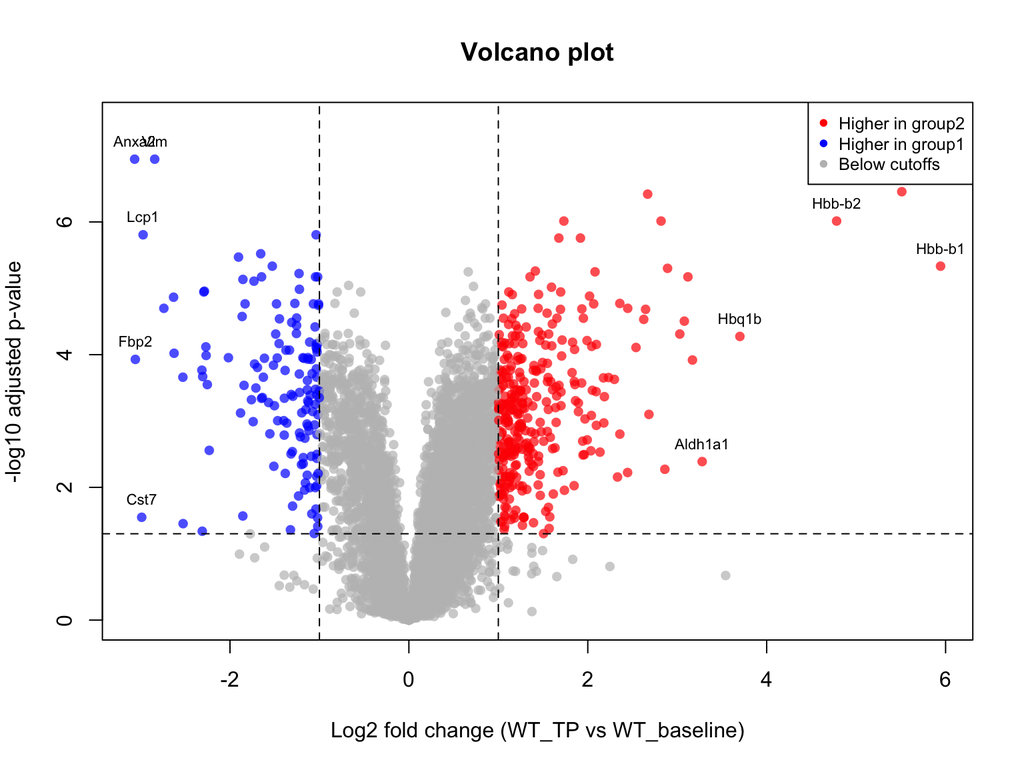

```r
par(mar = c(5, 4, 4, 2))
plot(volcano_df$log2fc, volcano_df$neglog10padj,
     ylim = c(0, 1.08 * max(volcano_df$neglog10padj, -log10(fdr_cutoff))),
     col = adjustcolor(volcano_df$color, alpha.f = 0.7), pch = 16,
     xlab = paste0("Log2 fold change (", group2, " vs ", group1, ")"),
     ylab = "-log10 adjusted p-value", main = "Volcano plot")
abline(h = -log10(fdr_cutoff), lty = 2)
abline(v = c(-fc_cutoff, fc_cutoff), lty = 2)
text(label_df$log2fc, label_df$neglog10padj, labels = label_df$name, pos = 3, cex = 0.7)
legend("topright", legend = names(plot_colors), col = plot_colors, pch = 16, cex = 0.8)
```

## Volcano plot with ggplot2

The ggrepel package helps keep the labels from overlapping. We will reuse the same table and cutoffs so both plots show the same analysis. We will also let the data determine the axes, rather than hide points with fixed limits.

```r
install.packages("ggrepel")
```

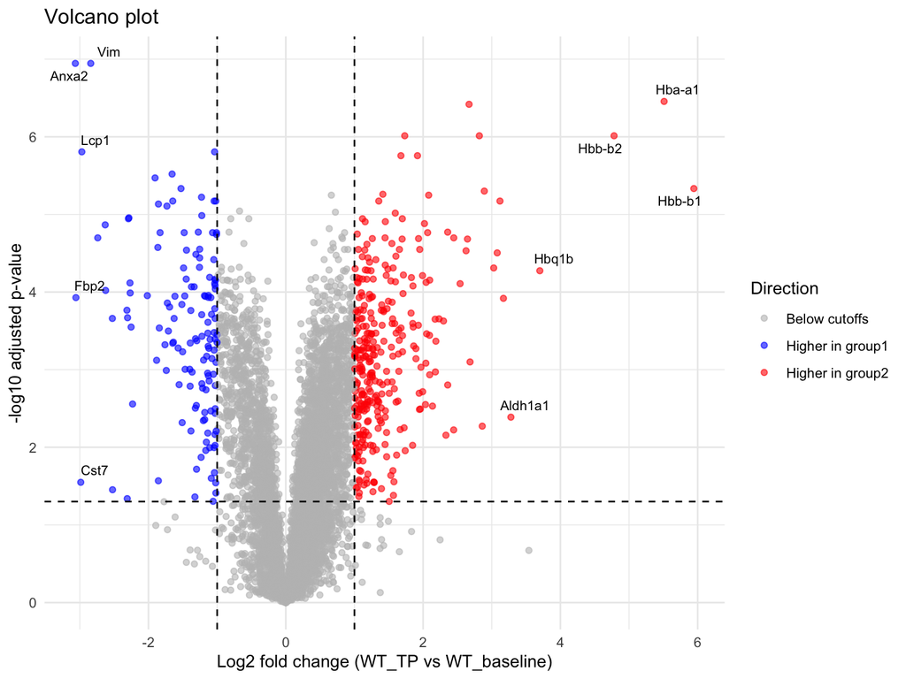

```r
library(ggrepel)
ggplot(volcano_df, aes(x = log2fc, y = neglog10padj, color = direction)) +
  geom_point(alpha = 0.6) +
  geom_vline(xintercept = c(-fc_cutoff, fc_cutoff), linetype = "dashed") +
  geom_hline(yintercept = -log10(fdr_cutoff), linetype = "dashed") +
  geom_text_repel(data = label_df, aes(label = name), color = "black",
                  size = 3, max.overlaps = Inf, show.legend = FALSE, seed = 1) +
  scale_color_manual(values = plot_colors) +
  labs(title = "Volcano plot", x = paste0("Log2 fold change (", group2, " vs ", group1, ")"),
       y = "-log10 adjusted p-value", color = "Direction") +
  theme_minimal()
```

## Pathway enrichment analysis

We have a list of proteins that pass both cutoffs. Are some KEGG pathways represented in that list more often than we would expect? Enrichr uses the gene symbols to check. We will use the mouse library and start with the proteins higher in `group2`.

```r
higher_proteins = subset(protein_results,
  differentially_expressed & group2_group1_log2fc > 0 & !is.na(gene_symbol))
higher_genes = unique(higher_proteins$gene_symbol)
head(higher_genes)
```

```
## [1] "Hebp1"  "Dock6"  "Ampd3"  "Nt5dc2" "Prdm2"  "Brwd3"
```

```r
length(higher_genes)
```

```
## [1] 262
```

`unique()` gives us one entry per gene. Enrichr sends the gene symbols to its web service, so the live call needs an internet connection. Install the package once if you need it.

```r
install.packages("enrichR")
```

Run the chunk below to submit `higher_genes` to Enrichr and get the mouse KEGG pathway results.

```r
library(enrichR)
enrichment = enrichr(higher_genes, "KEGG_2019_Mouse")
```

```
## Uploading data to Enrichr... Done.
##   Querying KEGG_2019_Mouse... Done.
## Parsing results... Done.
```

```r
kegg_results = enrichment[["KEGG_2019_Mouse"]]
```

We asked for one library. The line with the double brackets pulls that library’s table out of the results. Look at `Term` for the pathway name, `Adjusted.P.value` for the adjusted p-value, and `Overlap` for how many of our genes hit that pathway. `Genes` gives the names of the matching genes.

```r
head(kegg_results[, c("Term", "Overlap", "Adjusted.P.value")])
```

```
##                                   Term Overlap Adjusted.P.value
## 1 Porphyrin and chlorophyll metabolism    7/41     0.0001840632
## 2                             Lysosome   9/124     0.0035867146
## 3                            Autophagy   9/130     0.0035867146
## 4                    Sulfur metabolism     3/9     0.0086288536
## 5               FoxO signaling pathway   8/132     0.0138956549
## 6     Mucin type O-glycan biosynthesis    4/28     0.0150277933
```

```r
kegg_results$Genes[1]
```

```
## [1] "ALAD;ALAS2;FECH;UROD;UROS;BLVRB;PPOX"
```

### Plot the top KEGG pathways

Sort the table by adjusted p-value and use `head()` to take the first ten rows. Just as in the volcano plot, smaller adjusted p-values become larger values after `-log10()`. `rev()` puts the smallest p-value at the top of the horizontal bar plot. The dashed line marks an adjusted p-value of 0.05.

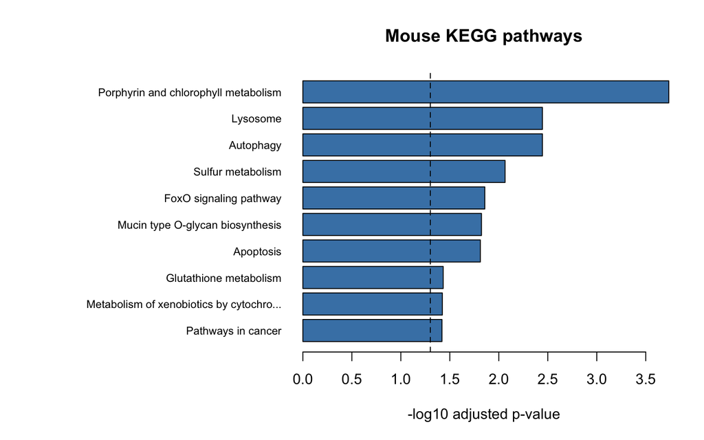

```r
kegg_sorted = kegg_results[order(kegg_results$Adjusted.P.value), ]
top_kegg = head(kegg_sorted, 10)
bar_heights = -log10(top_kegg$Adjusted.P.value)
pathway_names = str_trunc(top_kegg$Term, 40)

old_margins = par(mar = c(5, 17, 4, 2))
barplot(rev(bar_heights), names.arg = rev(pathway_names), horiz = TRUE,
        col = "steelblue", las = 1, cex.names = 0.75,
        xlab = "-log10 adjusted p-value", main = "Mouse KEGG pathways")
abline(v = -log10(0.05), lty = 2)
```

```r
par(old_margins)
```

Which bars cross the line? Pick one and read its matching genes in the results table. Enrichment tells us that genes from a pathway appear often in our list. To interpret the finding, look at which genes contributed and what the experiment measured.

## Save the results

```r
write.table(protein_results, "work/day1_protein_differential_abundance.tsv",
            sep = "\t", quote = FALSE, row.names = FALSE)
writeLines(capture.output(sessionInfo()), "work/day1_sessionInfo.txt")
```

Use this chunk to save the pathway results from Enrichr.

```r
write.table(kegg_results, "work/day1_enrichr_kegg.tsv",
            sep = "\t", quote = FALSE, row.names = FALSE)
```

## Questions

1. How many proteins pass both cutoffs? How many could not be tested?
2. What happens if you change fc_cutoff from log2(2) to log2(1.5)? Keep the FDR threshold fixed and rerun the downstream chunks.
3. Try making a histogram of the finite log2 fold changes with hist(). Does the distribution look symmetric?
4. Among proteins higher in group2, which has the 42nd-smallest adjusted p-value? If there are fewer than 42, how would you avoid selecting a nonexistent row?
5. Make a gene list from proteins that pass both cutoffs and are higher in `group1`. Repeat the enrichment and compare the pathways from the two directions.
6. Pick one pathway in the bar plot. Use the `Genes` column for that pathway to find the genes that contributed.
7. Change `group1` and `group2` to compare `KO_baseline` with `KO_TP`. Rerun from `choose-comparison` through the volcano plot. To see which pathways come up for KO, submit the new KO gene list to Enrichr. Does a difference in significance between WT and KO prove a genotype-by-treatment interaction? (Hint: that needs an interaction test.)

# Knit to HTML or PDF

This R Markdown file can make both an HTML report and a PDF. Use the menu next to **Knit** in RStudio and choose **Knit to HTML** or **Knit to PDF**. To make a PDF, you need a LaTeX installation. TinyTeX is one option.

If you need LaTeX, run these two commands once in the R console. Restart RStudio when installation finishes, then choose **Knit to PDF**. [TinyTeX documentation](https://yihui.org/tinytex/).

```r
install.packages("tinytex")
tinytex::install_tinytex()
```

To make both reports at once, run this in the console with `mass_spec_multi-omics_2026.Rproj` open. [R Markdown render documentation](https://rmarkdown.rstudio.com/docs/reference/render.html).

```r
rmarkdown::render("scripts/Day01_proteomics.Rmd", output_format = "all")
```

# Further reading

I highly recommend *Practical Statistics for Data Scientists* for a deeper look at the ideas we used today, including exploratory plots, sampling, and significance testing. It has worked examples in R and Python. It is a paid book from O’Reilly. [Practical Statistics for Data Scientists, 2nd edition](https://www.oreilly.com/library/view/practical-statistics-for/9781492072935/).

Ever feel lost about which statistical test to use? John McDonald’s free handbook walks through how to choose a test and interpret it using examples from biology. The separate R companion shows how to run many of those examples in R. [Handbook of Biological Statistics](https://www.biostathandbook.com/), [Choosing a statistical test](https://www.biostathandbook.com/testchoice.html), [R Companion](https://rcompanion.org/rcompanion/).

If you would like to continue building your skills in R and data analysis, a great place to start is Roger D. Peng’s open-access (free) book *R Programming for Data Science*: https://bookdown.org/rdpeng/rprogdatascience/. It introduces many foundational ideas in R programming and data science in a practical and approachable way.

For topics more specific to genomics and bioinformatics workflows, *Computational Genomics with R* by Altuna Akalin is another excellent resource: https://compgenomr.github.io/book/. It covers a range of common bioinformatics tasks, including working with sequencing data, visualization, and downstream analysis using R and Bioconductor.

Looking for inspiration on how to visualize your data in R? Explore the R Graph Gallery: https://r-graph-gallery.com

Want to see some of these concepts applied in cutting-edge proteogenomics research? Take a look at recent CPTAC papers, such as this one: https://pubmed.ncbi.nlm.nih.gov/38359819/

Although this workshop focuses on proteomics, many of the same principles and tools apply across bioinformatics domains. Bioinformatics is, at its core, biological data science. Most well-written data science resources are directly relevant and can help you continue to grow your skills.

# How to get help

Many common questions and answers: https://stackoverflow.com (top Google search hits for error messages and problems with R usually have some links to here).

Amazing for debugging code and troubleshooting error messages https://chatgpt.com.

Need to ask someone for help? Make a SSCCE https://sscce.org.

Package/library references: [ComplexHeatmap](https://bioconductor.org/packages/ComplexHeatmap/), [Enrichr](https://maayanlab.cloud/Enrichr/), [limma user guide](https://bioconductor.org/packages/limma/).